# Marketing Analytics

Chapter 3 · Uncertainty

Nils Wlömert

Vienna University of Economics and Business (WU)

October 2026

## Before we start

**Paper quiz on Chapter 2** *(10 min)*

- Individual, closed book
- Counts toward participation

**Assignment 1** is running

- Deadline: Group A Mon, Oct 26 · Group B Wed, Oct 28
- Debrief at the start of next session
- Questions? → forum on Canvas

## Today’s session

**Part A — Uncertainty** *(this deck)*

3.1 Is the difference real?  
3.2 Populations and samples  
3.3 Sampling variation  
3.4 The standard error  
3.5 The central limit theorem  
3.6 Confidence intervals  
3.7 Shares and the margin of error  
3.8 Uncertainty in R

**Part B — Experiments I** *(next deck)*

Comparing two groups: is the difference larger than sampling variation alone would produce?

**Driving question:** *How sure can I be?* Every number from a sample is an estimate — today we learn to say **how good** an estimate it is.

# 3.1 Is the difference real?

## An A/B test at a streaming service

- New feature **Smart Mix**: a personalized daily mix on the home screen
- **400 randomly selected users**, randomly split: 200 see Smart Mix, 200 the usual home screen
- Outcome: **listening hours** in the four weeks after the start
- The dashboard shows the two group means →

**Would you roll it out?** What would you want to know before deciding?

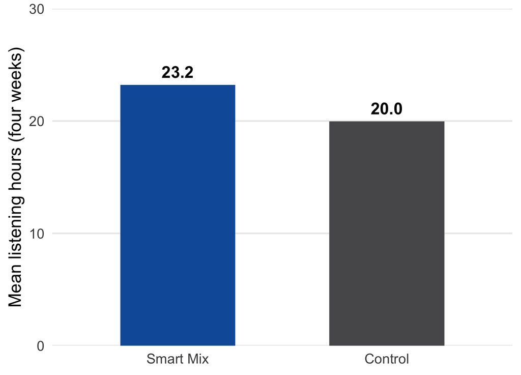

## Look at the data

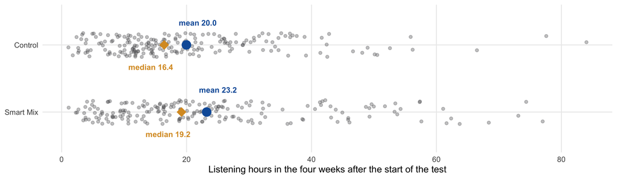

- **200 users per group**, each dot one user
- The two clouds **overlap almost completely**
- A few **heavy listeners** on the right pull each mean up — the medians (16.4 vs. 19.2) sit below the means

Same 3.2-hour difference — but now we see **how many** users, **how dispersed** they are, and that the means are **pulled by outliers**. Would you still roll it out? Could 3.2 hours be the luck of the draw?

## Real effect — or luck of the draw?

```r
t.test(hours ~ group, data = ab_test)
```

```
    Welch Two Sample t-test

data:  hours by group
t = 2.1617, df = 386.96, p-value = 0.03125
alternative hypothesis: true difference in means between group Smart Mix and group Control is not equal to 0
95 percent confidence interval:
 0.293571 6.196096
sample estimates:
mean in group Smart Mix   mean in group Control
               23.21980                19.97497
```

With **another 400 users**, would the difference be the same? Could Smart Mix do **nothing at all**? What do *t*, the *p*-value, and the “95 percent confidence interval” tell us?

## Why statistical inference?

- The team observed **400 users** — the decision concerns **all users** (millions)
- 400 users = **sample**; all users = **population**
- The group means — and their difference — are **estimates**: another random sample, another number

**Randomization** makes the comparison **fair** (§1.6).

**Statistical inference** tells us whether it is **precise enough** to tell a real effect from the noise of sampling.

## Thought experiment 1: what if the sample were larger?

**2,000 users per group** instead of 200 — with *exactly* the same group means:

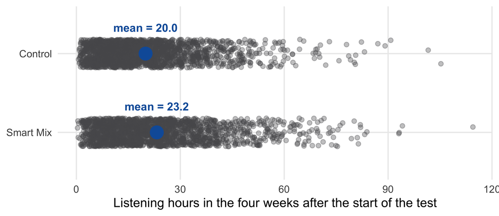

```r
t.test(hours ~ group, data = ab_large)
```

```
    Welch Two Sample t-test

data:  hours by group
t = 6.8057, df = 3960.5, p-value = 0.00000000001157
alternative hypothesis: true difference in means between group Smart Mix and group Control is not equal to 0
95 percent confidence interval:
 2.310072 4.179595
sample estimates:
mean in group Smart Mix   mean in group Control
               23.21980                19.97497
```

Same difference of 3.2 hours — but *t* = 6.8 instead of 2.2, *p* = 0.00000000001 instead of 0.03, and the interval shrinks from [0.3; 6.2] to [2.3; 4.2]. **More users → less uncertainty about the same difference.**

## Thought experiment 2: what if users were more similar?

**The same 400 users**, each pulled halfway toward their group mean — means unchanged, spread halved:

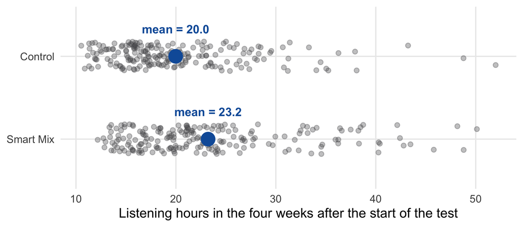

```r
t.test(hours ~ group, data = ab_similar)
```

```
    Welch Two Sample t-test

data:  hours by group
t = 4.3234, df = 386.96, p-value = 0.00001957
alternative hypothesis: true difference in means between group Smart Mix and group Control is not equal to 0
95 percent confidence interval:
 1.769202 4.720465
sample estimates:
mean in group Smart Mix   mean in group Control
               23.21980                19.97497
```

Same means, same *n* — but *t* = 4.3, *p* = 0.00002, interval [1.8; 4.7]. **Less spread within the groups → less uncertainty about the same difference.**

## Two ingredients of uncertainty

|  | Users per group | Spread (SD) | *t* | *p* |
| --- | --- | --- | --- | --- |
| Original test | 200 | 16 / 14 | 2.2 | 0.03 |
| Larger sample | 2,000 | 16 / 14 | 6.8 | < 0.001 |
| More similar users | 200 | 8 / 7 | 4.3 | < 0.001 |

The difference was **3.2 hours** in all three cases. What changed is **how sure** we can be about it — and that depends on only two things: **how many** users, and **how different** they are from each other.

Today’s chapter shows where this comes from: the **standard error**, $\sigma / \sqrt{n}$ — spread divided by the square root of the sample size (§3.4).

## The plan for this chapter

**The A/B test stays with us.** Its outcome is **continuous** → the uncertainty of a **mean**:

- 3.3 How much does a sample mean vary?
- 3.4 Measuring it: the **standard error**
- 3.5 Why the normal distribution keeps showing up
- 3.6 From an estimate to a **confidence interval**

**Then the same question for shares** (converted / not, voted for / not):

- 3.7 The margin of error of an **election poll**
- 3.8 Everything in R — and the A/B test output stops being a mystery

One question throughout: **if we had drawn a different sample, how different could our number have been — and how far could it be from the truth?**

# 3.2 Populations and samples

## From the sample to the population

- **Population:** the whole group we want to learn about (all voters, all customers, all WU students)
- **Census:** data from *every* member — rare, expensive, often impossible
- **Sample:** a subgroup we actually observe
- **Statistical inference:** generalizing from the sample to the population

|  | Sample (statistic) | Population (parameter) |
| --- | --- | --- |
| Size | $n$ | $N$ |
| Mean | $\bar{x}$ | $\mu$ |
| Standard deviation | $s$ | $\sigma$ |
| Share | $\hat{p}$ | $p$ |

Parameters: what we want to know. Statistics: what we can compute.

## How the sample is drawn matters

|  | Probability sampling | Non-probability sampling |
| --- | --- | --- |
| **Principle** | Known chance of selection; **random** | Convenience or researcher’s judgment |
| **Techniques** | Simple random · stratified · cluster · systematic | Convenience · quota · judgmental · snowball |
| **Uncertainty** | Can be **quantified** | Cannot be quantified reliably |

**Typical sources of selection bias:** *under-coverage* (not in the sampling frame) · *non-response* (non-respondents differ) · *voluntary response* (only the strongly opinionated answer)

**Your group project** uses a convenience sample — fine for learning, but be honest about it. The good news: your **experiment** is still fair, because conditions are randomized *within* the sample (§1.6).

## Two kinds of error

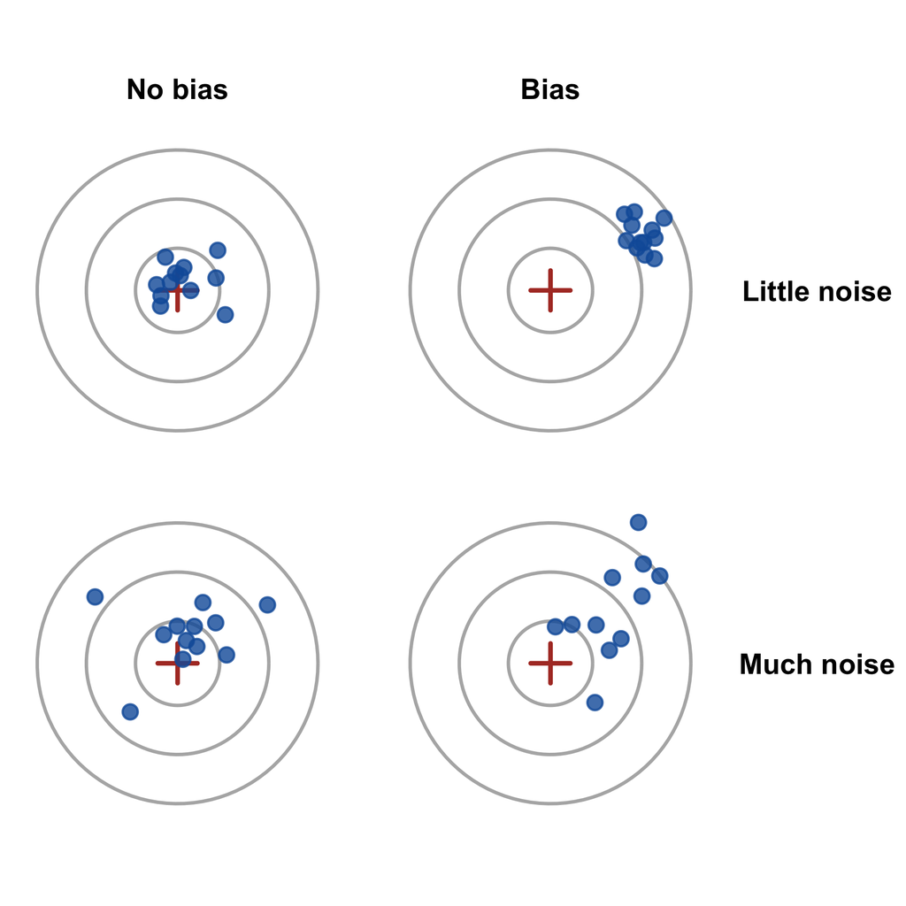

**Random error** (sampling variation)

- Each sample is a slightly different mix of people
- **Quantifiable** — and **shrinks** with larger samples
- The margin of error is about this kind

**Systematic error** (bias)

- The sample differs from the population *systematically*
- A larger sample **does not help** — “more confidently wrong” (§1.6)

*Under-coverage, non-response, voluntary response → **systematic** error. In the A/B test, randomization rules out bias in the comparison — random error remains.*

# 3.3 Sampling variation

## A world in which we know the truth

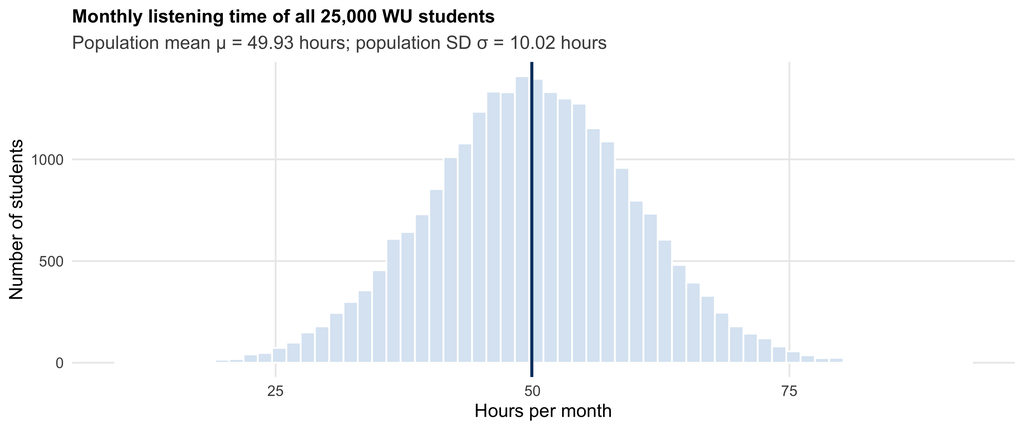

Monthly listening time of all **25,000 WU students** — simulated, so we know the true values. In reality we never do: that is why we sample.

## One sample, then another

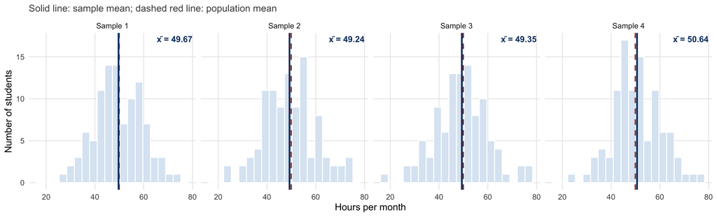

**Sampling variation:** each random sample of 100 students gives a slightly different mean. Not a mistake — the unavoidable price of looking at a part instead of the whole. The question is only: **how large** is it?

## Live demo: the sampling machine

Course book, §3.3 — **draw 1, then 100, then 1,000 samples** and watch the means pile up.

https://wu-rds.github.io/MA2026/03-uncertainty.html#sec-unc-sampling

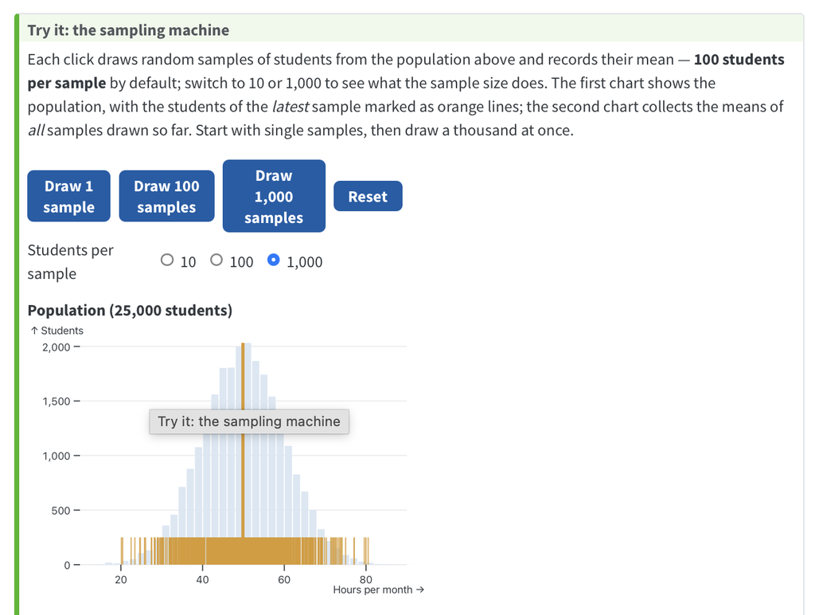

Before clicking “1,000 samples”: where will the sample means pile up — and how far from the true mean will the most extreme ones be?

## The sampling distribution

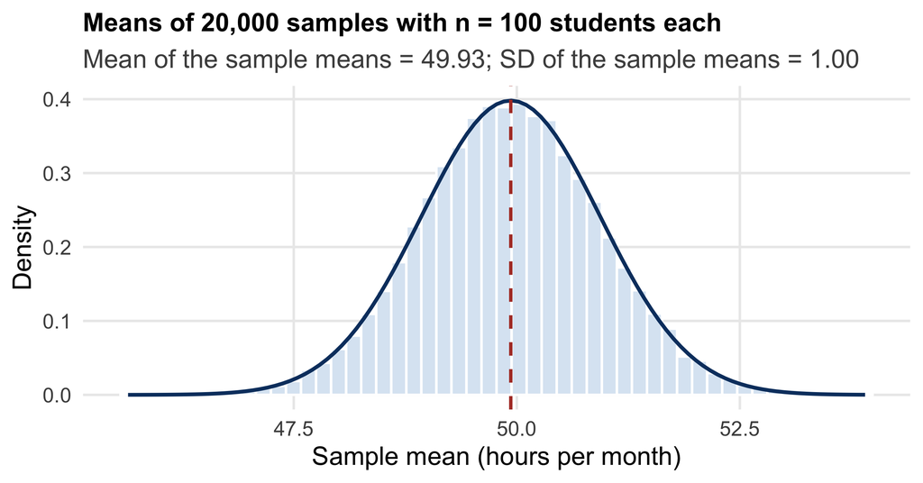

The means of *many* samples:

1. **Centered on the truth** — no over- or underestimation on average
2. **A known width** — the *standard error*
3. **A known shape** — normal (even for non-normal data, §3.5)

We only ever have **one** sample — but these three properties tell us how much to trust it.

# 3.4 The standard error

## How precise is a sample mean?

The width of the sampling distribution:

$$\sigma_{\bar{x}} = \frac{\sigma}{\sqrt{n}}$$

- $\sigma$: variability in the population
- $n$: sample size

Our example: 10 / $\sqrt{100}$ = **1.00** hours

**Square-root law:** four times the sample, half the standard error — **diminishing returns**. This is why polls survey ~1,000 people, not 10,000.

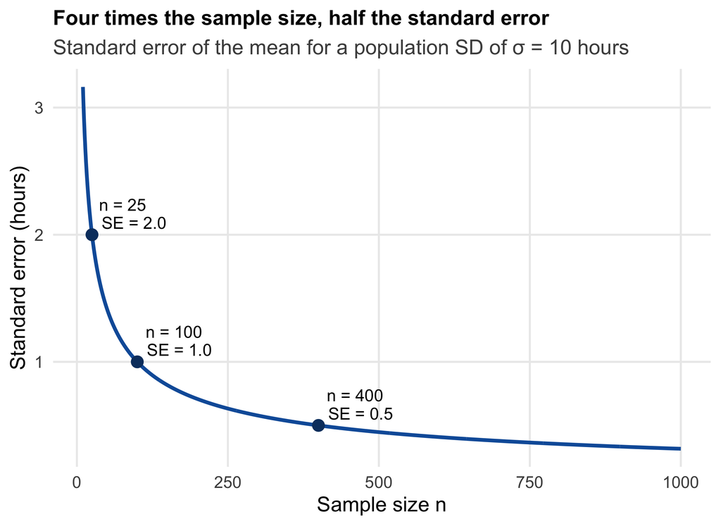

## What drives the standard error

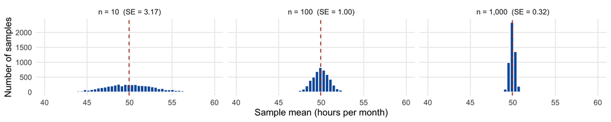

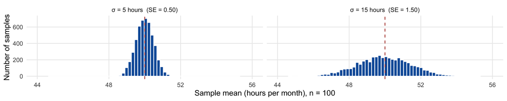

**Larger samples** → sample means cluster more tightly. **More variable populations** → sample means scatter more.

## Live demo: what drives the standard error?

Course book, §3.4 — move the sliders for **n** and **σ**.

https://wu-rds.github.io/MA2026/03-uncertainty.html#sec-unc-se

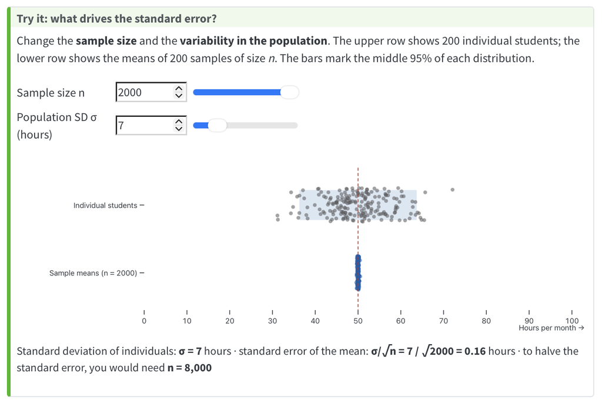

Your sample of **100 students** gives a standard error of **1 hour** per month. Your boss wants **half an hour**. How many students do you need?

## Standard deviation vs. standard error

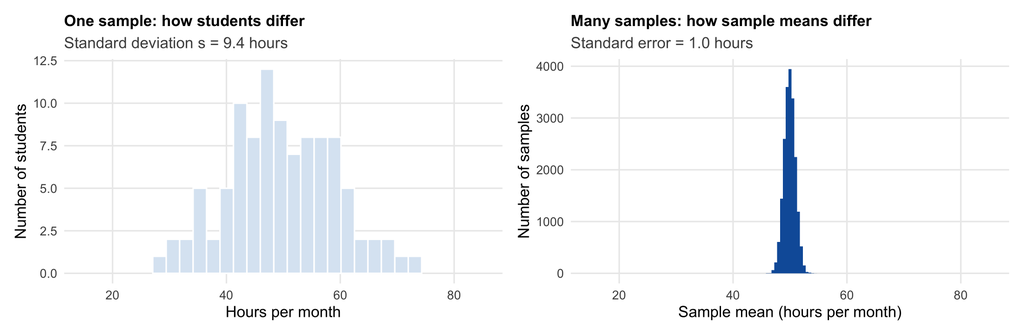

**SD:** how much **individuals** differ. A property of the data — does *not* shrink with more data.

**SE:** how much **sample means** would differ. The precision of the estimate — shrinks with $\sqrt{n}$.

## In practice: estimate σ with s

We never know $\sigma$ — so we use the sample standard deviation $s$:

$$SE_{\bar{x}} = \frac{s}{\sqrt{n}}$$

**Which one to report?** Describe how customers differ → **SD**. Describe how precisely you estimated the mean → **SE** or a **confidence interval**. Error bars in charts must say which one they show.

# 3.5 The central limit theorem

## What if the data are not normal?

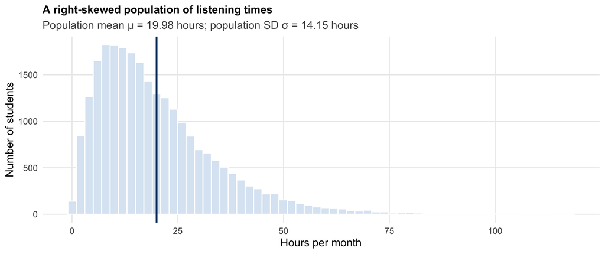

Marketing data are rarely normal: sales, visits, streams, revenue — **most customers a little, a few a lot**.

## Sample means become normal anyway

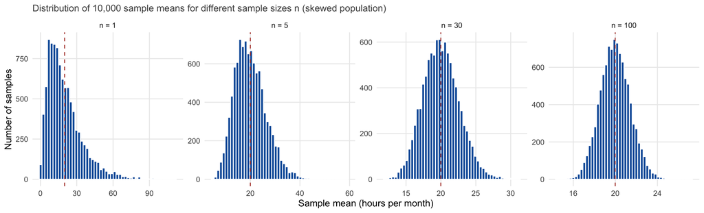

**Central limit theorem:** whatever the shape of the population, the **means** of samples become normally distributed as $n$ grows — centered on $\mu$, with width $\sigma / \sqrt{n}$.

## Live demo: the central limit theorem

Course book, §3.5 — choose a population shape, increase **n** step by step.

https://wu-rds.github.io/MA2026/03-uncertainty.html#sec-unc-clt

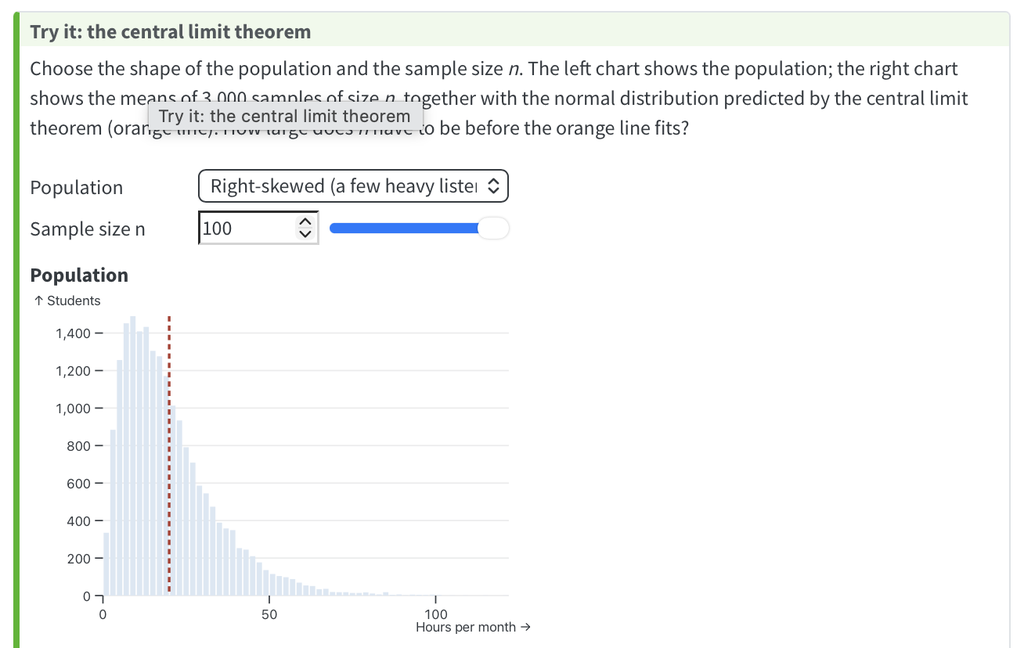

**Why it matters:** we do not need normal *data* — we need a normal *sampling distribution*. “n ≥ 30” is a rule of thumb, not a law: for extremely skewed data (streams!) you need much more.

# 3.6 Confidence intervals

## From a point to an interval

**Point estimate:** “the average listening time is 49.2 hours”

**Interval estimate:** “… between 47.2 and 51.3 hours”

**Casting a net:** we cannot see the true mean — but we can throw a net around our estimate that catches it most of the time.

$$\text{CI} = \text{estimate} \pm \underbrace{\text{critical value}}_{\text{how sure we want to be}} \times \underbrace{\text{standard error}}_{\text{how much the estimate wobbles}}$$

Net metaphor after Radziwill (2015), *Statistics (The Easier Way) with R*.

## Constructing a 95% confidence interval

- Sample means are normal around $\mu$ with SD = SE → 95% lie within **± 1.96 SE**
- Turned around: $\bar{x} \pm 1.96 \times SE$ catches $\mu$ in 95% of all samples

True mean: 49.93 — inside. This time.

## What “95% confidence” means

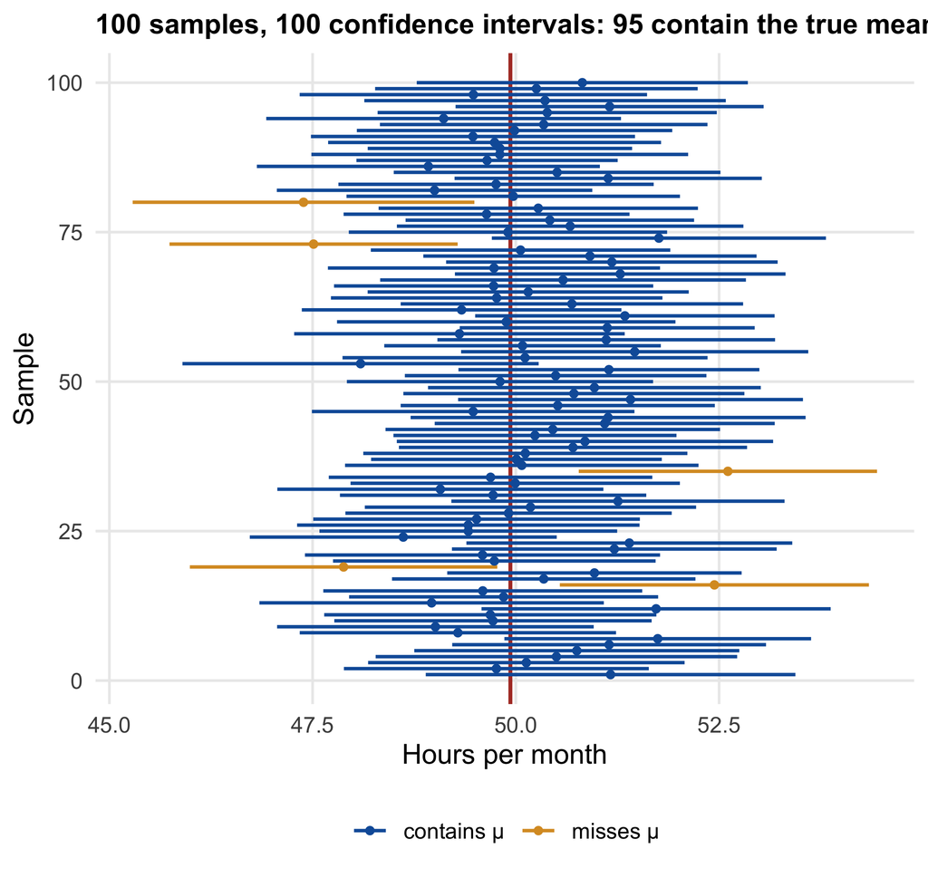

The confidence refers to the **method**: of all intervals constructed this way, **~95% contain** the true mean.

**Not quite right:** “95% probability that μ is in *this* interval” — a specific interval either contains μ or not. **Fine in practice:** “we are 95% confident that …” — remembering that ~1 in 20 such intervals is wrong.

## Live demo: how often does the net catch the truth?

Course book, §3.6 — draw batches of 100 intervals; change **n** and the **confidence level**.

https://wu-rds.github.io/MA2026/03-uncertainty.html#sec-unc-ci

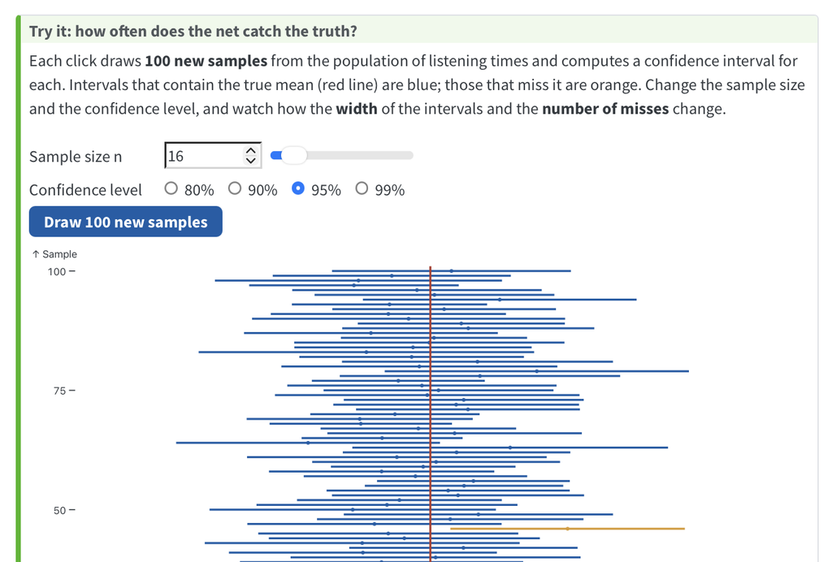

What happens to the **width** and to the **number of misses** when you (a) increase *n*, (b) switch from 95% to 99%?

## Confidence level vs. width

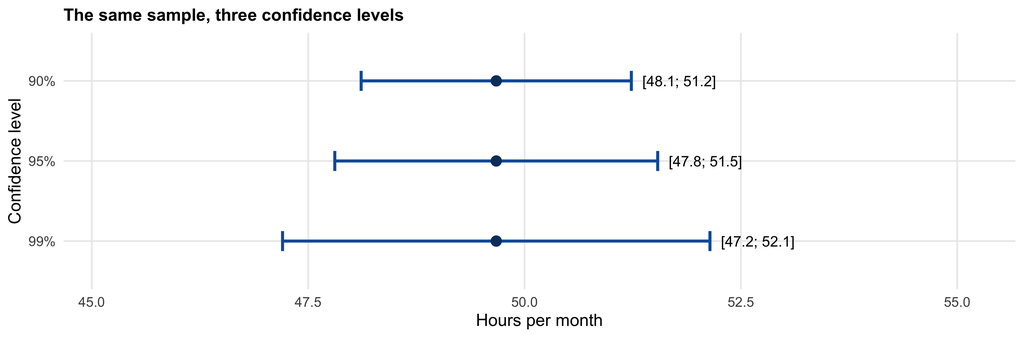

- More confidence → **wider** net (99%: 2.58 instead of 1.96)
- Narrow **and** reliable → only via **larger n**

| *n* | 10 | 30 | 100 | ∞ |
| --- | --- | --- | --- | --- |
| *t* value (95%) | 2.26 | 2.05 | 1.98 | 1.96 |

Small samples: *t*-distribution — R does it automatically

# 3.7 Shares and the margin of error

## “Plus or minus 3.1 percentage points”

> “The poll was conducted Sept. 13–17 and surveyed 1,000 registered voters nationally. The margin of error is plus or minus 3.1 percentage points.”

> — NBC News, September 2024

The same question for a **share**: more than 150 million people voted. How can **1,000** respondents tell us anything? Where does **± 3.1** come from — and why not survey 10,000?

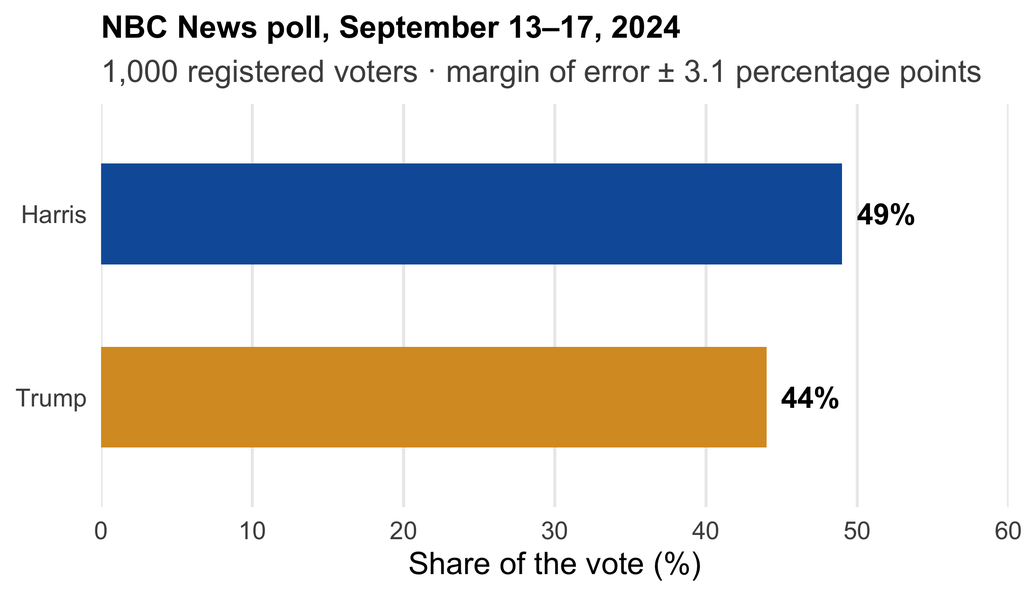

## Many polls, one truth

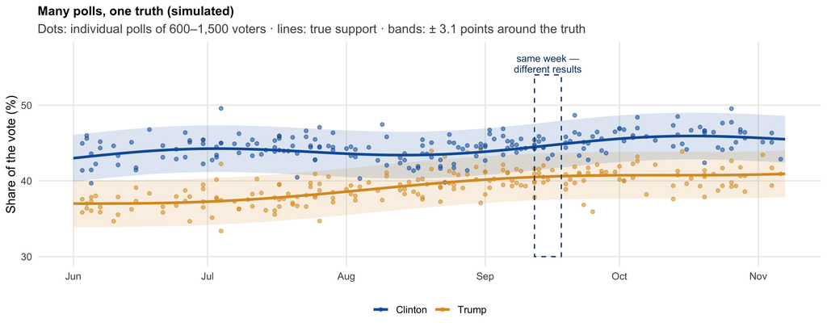

Polls taken in the **same week** come to **different results** — each one is a different random sample. Most of them stay within **± 3 points** of the truth. That is what the margin of error describes.

## And then the polls were wrong

- 2016: state polls in several Midwestern states **underestimated Trump’s support by more than their margins of error**
- Post-election analyses: late deciders; **voters without a college degree underrepresented** and not corrected for
- The margin of error did not warn — because it only covers **random** error, not the **systematic** error of 3.2

Kennedy et al. (2018), “An Evaluation of the 2016 Election Polls in the United States”, *Public Opinion Quarterly*, 82(1), 1–33.

## Decoding “± 3.1 percentage points”

Standard error of a share:

$$SE_{\hat{p}} = \sqrt{\frac{\hat{p}\,(1-\hat{p})}{n}}$$

Margin of error = $1.96 \times SE_{\hat{p}}$, largest at $\hat{p}$ = 50%:

$$1.96 \times \sqrt{\tfrac{0.5 \times 0.5}{1{,}000}} = \mathbf{0.031}$$

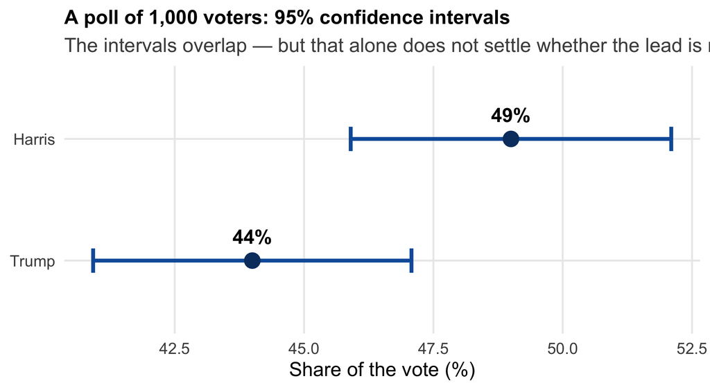

The margin of error of the **lead** is roughly **twice** as large: even the 5-point lead in this poll is not a safe lead.

## How many respondents do you need?

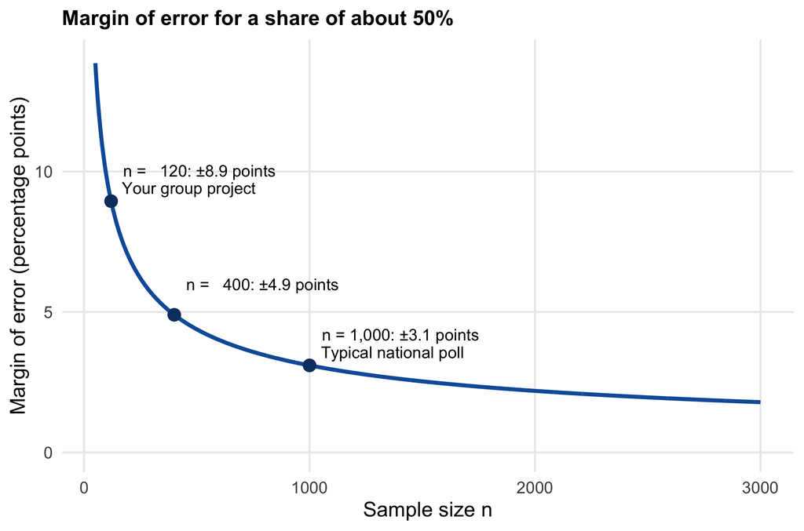

**Your group project** (~120 respondents): a share of ~50% comes with **± 9 points**. Think twice before interpreting a 5-point difference.

Live calculator: course book, §3.7

https://wu-rds.github.io/MA2026/03-uncertainty.html#sec-unc-proportions

# 3.8 Uncertainty in R

## A confidence interval for a mean

```r
set.seed(6789)
population <- rgamma(25000, shape = 2, scale = 10)      # the "unknown" population
listening  <- tibble(hours = sample(population, size = 100))
```

```r
n    <- nrow(listening)
xbar <- mean(listening$hours)
se   <- sd(listening$hours) / sqrt(n)
crit <- qt(0.975, df = n - 1)
c(mean = xbar, lower = xbar - crit * se, upper = xbar + crit * se)
```

```
    mean    lower    upper
19.77946 16.82950 22.72943
```

```r
t.test(listening$hours)$conf.int
```

```
[1] 16.82950 22.72943
attr(,"conf.level")
[1] 0.95
```

`qt(0.975, …)`: 2.5% in each tail. `t.test()` does it all in one line.

## Back to the A/B test: intervals per group

```r
ab_test |>
  group_by(group) |>
  summarise(n = n(), mean = mean(hours), se = sd(hours) / sqrt(n),
            lower = mean - qt(0.975, n - 1) * se,
            upper = mean + qt(0.975, n - 1) * se)
```

```
# A tibble: 2 × 6
  group         n  mean    se lower upper
  <fct>     <int> <dbl> <dbl> <dbl> <dbl>
1 Smart Mix   200  23.2 1.15   21.0  25.5
2 Control     200  20.0 0.968  18.1  21.9
```

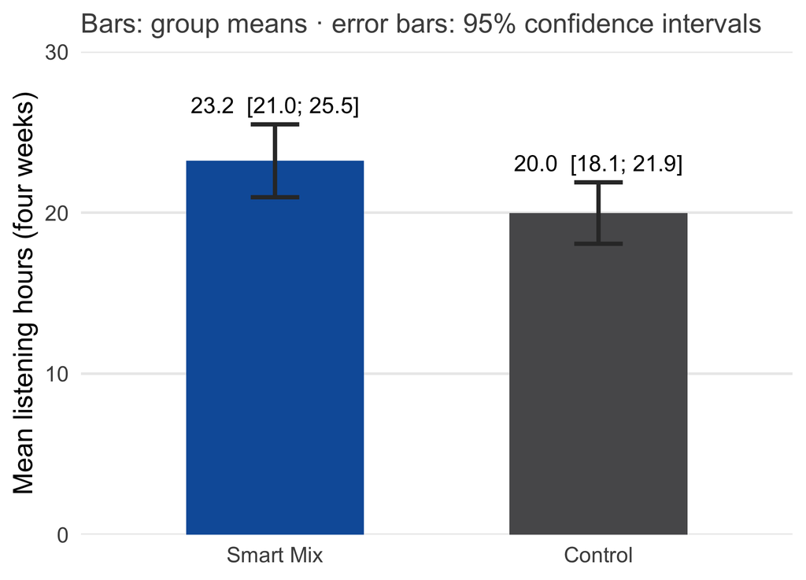

The bar chart from the start of the session — now **with intervals**. The two intervals **overlap** — no effect? Not necessarily: the decision depends on the uncertainty of the **difference**, which has its own standard error. The interval `t.test()` reported (0.29 to 6.20 hours) is exactly that → **Experiments I**.

## A confidence interval for a share

**Back to the poll: 1,000 voters, 49% Harris, 44% Trump**

```r
n_poll <- 1000
p_hat  <- c(Harris = 0.49, Trump = 0.44)
se_p   <- sqrt(p_hat * (1 - p_hat) / n_poll)
cbind(share = p_hat,
      lower = p_hat - 1.96 * se_p,
      upper = p_hat + 1.96 * se_p)
```

```
       share     lower     upper
Harris  0.49 0.4590159 0.5209841
Trump   0.44 0.4092336 0.4707664
```

**The same with `prop.test()`:**

```r
prop.test(x = 490, n = 1000)$conf.int
```

```
[1] 0.4586166 0.5214612
attr(,"conf.level")
[1] 0.95
```

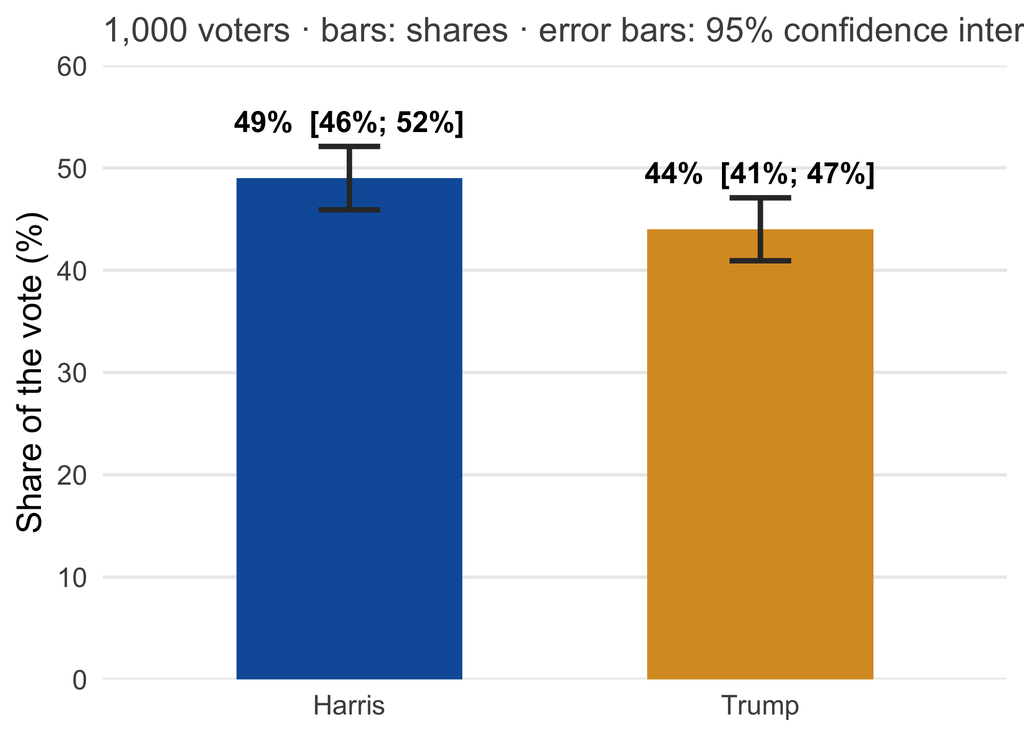

Each share ± about 3 points — the “± 3.1” from the news report, now computed. `prop.test()` takes the number of “successes” and the sample size; its interval differs slightly from the hand calculation (it uses the **Wilson score interval**, more reliable for small samples and shares near 0 or 1). **Sample size planning** follows in Chapter 4.

# What confidence intervals do not tell you

## Three limits

1. **Random error only.** A biased sample gives a precise but wrong estimate — a larger biased sample, a more precise and equally wrong one (2016 polls; §1.6; §2.5)
2. **Precision, not spread.** A narrow interval for the *average* does not mean customers are alike
3. **A statement about a procedure.** ~1 in 20 intervals misses — compute many, and some will

**Next:** back to Smart Mix — **+3.2 hours**: larger than sampling variation alone would produce? The difference has its own standard error — **the logic of today carries over one to one**, and we read the complete *t*-test output.

## Learning check

1. Smart Mix users listened about 3 hours more. Why does this difference alone not show that Smart Mix increases listening among **all** users?
2. A poll of 1,000 voters reports ± 3.1 points. How is this number calculated? Name one error it does **not** cover.
3. You double your survey from 400 to 800 respondents. By what factor does the standard error change?
4. Random sample of 180 users: mean listening time 7.34 hours/week, SD 6.87. Compute the 95% CI (critical value 1.96).
5. Your website survey (anyone can answer) has 20,000 responses and a very narrow CI. Why might it still mislead?